# Assessment 08 - Basic Plots

## **Histograms**

Now we are going to make a histogram.

**Instructions**

- Compute the population in millions and save it to the object `population_in_millions`
- Create a histogram of the state populations using the function `hist`

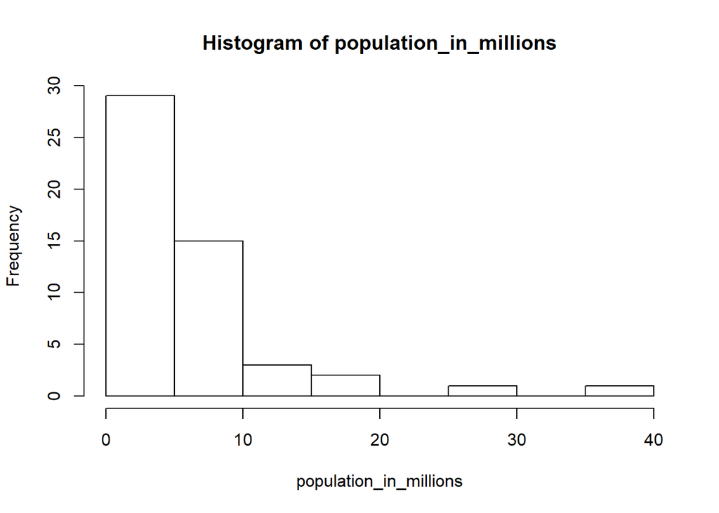

```r
# Store the population in millions and save to population_in_millions
population_in_millions <- murders$population/10^6

# Create a histogram of this variable
hist(population_in_millions)
```

## **Boxplots**

Now we are going to make boxplots. Boxplots are useful when we want a summary of several variables or several strata of the same variables. Making too many histograms can become too cumbersome.

**Instructions**

In one line of code:

- Stratify the state populations by region.
- Generate boxplots for the strate.

Note that you can achieve this using this `population~region` inside `boxplot` to generate the strata and specify the dataset with the `data` argument.

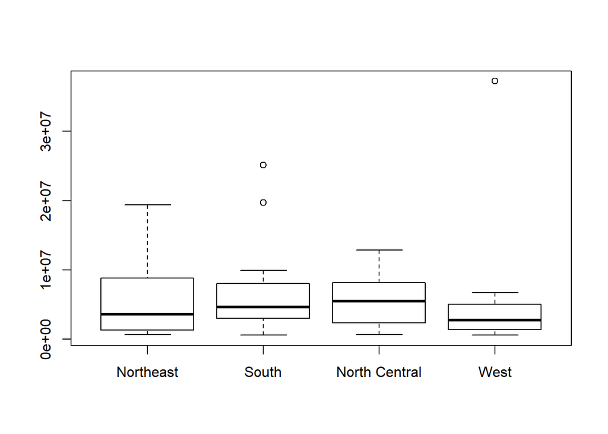

```r
# Create a boxplot of state populations by region for the murders dataset
boxplot(population~region,data=murders)
```